# CUDA LAB - TRINET SIAMESE MODEL

```python
import os
import random
import shutil
from tqdm import tqdm
import numpy as np
import matplotlib.pyplot as plt

from sklearn.model_selection import train_test_split
import torch
import torch.nn as nn
import torch.nn.functional as F
import torchvision
from torchvision import datasets, models, transforms
from torchvision.utils import save_image

from torchvision import datasets, models, transforms

import os
from PIL import Image
```

# Observations:

## 1) Acheived nice results in terms of clusters observed in embeddings of faces of George_W_Bush, Colin_Powell, Donald_Rumsfeld, Gerhard_Schroeder.

## 2) Fine-tuned resnet takes a longer time to run however gives slightly better results when visualising tsne projections of embeddings. (More on that later)

## 3) Sizes of 32 and 320 were used in both fine tuned and fixede fearure resnet and their comparisons are mentioned near their plots.

## 4) PCA projections of fixed-feature extractor looks way better than the fine-tuned resnet but I could not explain why so as I hoped for both pca and tsne to be better with fine-tuned resnet.

## 5) Below a function named "def weights_init(m)" was tried to initialise weights but it did not give any good results than the default method so it was not used in the results you will see below.

## 6) Sharp increase in Adjusted Random Index of embeddings compared to images.

## 7) The ARI was pretty close for all 4 models mentioned below i.e. between 1.3-1.39

### NOTE: For projections, the images of 4 people used are hard-coded with manual seed set at 42

## Loading the LFW Data:

```python
class ImageClass(object):
    "Stores the paths to images for a given class"
    def __init__(self, name, image_paths):
        self.name = name
        self.image_paths = image_paths

    def __str__(self):
        return self.name + ', ' + str(len(self.image_paths)) + ' images'

    def __len__(self):
        return len(self.image_paths)

def get_dataset(paths):
    dataset = []
    for path in paths.split(':'):
        path_exp = os.path.expanduser(path)
        classes = os.listdir(path_exp)
        classes.sort()
        nrof_classes = len(classes)
        for i in range(nrof_classes):
            class_name = classes[i]
            facedir = os.path.join(path_exp, class_name)
            if os.path.isdir(facedir):
                images = os.listdir(facedir)
                image_paths = [os.path.join(facedir,img) for img in images]
                dataset.append(ImageClass(class_name, image_paths))

    return dataset, classes
```

```python
class DataLoader():
    def __init__(self, dir_path, transform):
        self.images_dict = {}
        self.id2image = {}
        self.labels = None
        self.dir_path = dir_path
        self.transform = transform
        self.load_images()

    def load_images(self):
        # returns labels/names list
        self.labels = os.listdir(self.dir_path)
        for label in self.labels:
            path = os.path.join(self.dir_path, label)
            images = os.listdir(path)
            self.images_dict[label] = images
            for image_id in images:
                img_path = os.path.join(path, image_id)
                self.id2image[image_id] = self.transform(Image.open(img_path))

    def gen_data(self):
        labels = []
        image_ids = []
        for label, images in self.images_dict.items():
            num_images = len(images)
            labels.extend([label] * num_images)
            image_ids.extend(images)
        return image_ids, labels

    def get_image(self, image_id):
        return self.id2image[image_id]
```

## Tensor Transformations applied

```python
from torchvision import transforms
mean1=[0.6071, 0.4609, 0.3944]
std1=[0.2457, 0.2175, 0.2129]
transform = transforms.Compose([
        transforms.Resize((250,250)),  # make 250x250
        transforms.CenterCrop(150),   # then take 150x150 center crop
        transforms.Resize((200,200)),  # resized to the network's required input size
        transforms.ToTensor(),
        transforms.Normalize(mean = mean1,
                             std = std1),
    ])
```

```python
dataset = DataLoader("data/faces/lfw", transform)
```

```python
dataset.load_images()
im_id, im_label = dataset.gen_data()
```

```python
im_data = torch.empty(len(im_id),dataset.get_image(im_id[0]).size(0),dataset.get_image(im_id[0]).size(1),dataset.get_image(im_id[0]).size(2))
im_data.shape
```

```
torch.Size([13233, 3, 200, 200])
```

```python
for i in range(len(im_id)):
    b = dataset.get_image(im_id[i])
    im_data[i,:] = b
```

```python
idx = 10
arr = im_data[idx,:,:,:].cpu().detach().numpy()
arr.transpose(1,2,0).shape
```

```
(200, 200, 3)
```

```
Clipping input data to the valid range for imshow with RGB data ([0..1] for floats or [0..255] for integers).
```

```
Aaron_Tippin
```

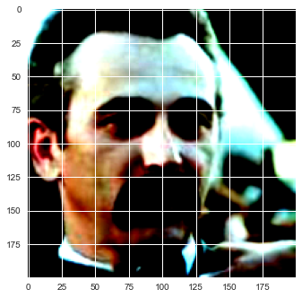

```python
plt.imshow(arr.transpose(1,2,0))
print(im_label[idx])
```

```python
im_data.shape
```

```
torch.Size([13233, 3, 200, 200])
```

```python
import gc
del dataset
gc.collect()
```

```
3357
```

```python
len(im_label)
```

```
13233
```

## Changing names to Integer labels

```python
import pandas as pd
px = pd.DataFrame(im_label)
px.columns = ["names"]
px.head(10)
```

|  | names |
| --- | --- |
| 0 | Aaron_Eckhart |
| 1 | Aaron_Guiel |
| 2 | Aaron_Patterson |
| 3 | Aaron_Peirsol |
| 4 | Aaron_Peirsol |
| 5 | Aaron_Peirsol |
| 6 | Aaron_Peirsol |
| 7 | Aaron_Pena |
| 8 | Aaron_Sorkin |
| 9 | Aaron_Sorkin |

```python
px.names = pd.factorize(px.names)[0]
px.head(10)
```

|  | names |
| --- | --- |
| 0 | 0 |
| 1 | 1 |
| 2 | 2 |
| 3 | 3 |
| 4 | 3 |
| 5 | 3 |
| 6 | 3 |
| 7 | 4 |
| 8 | 5 |
| 9 | 5 |

```python
p_list = px.values.tolist()
```

```python
torch_tensor = torch.tensor(px['names'].values, dtype = torch.int32)
```

```python
train_img_dataset, val_img_dataset, test_img_dataset = torch.utils.data.random_split(im_data, [9000,2000, 2233], generator=torch.Generator().manual_seed(42))
train_img_label, val_img_label, test_img_label = torch.utils.data.random_split(torch_tensor, [9000,2000, 2233], generator=torch.Generator().manual_seed(42))
```

```python
class TripletDataset:
    """
    Dataset class from which we sample random triplets
    """
    def __init__(self, dataset, labeling):
        """ Dataset initializer"""
        self.dataset = dataset
        self.arange = np.arange(len(dataset))
        self.labels = torch.Tensor([l for l in labeling])
        return

    def __len__(self):
        """ Returning number of anchors """
        return len(self.dataset)

    def __getitem__(self, i):
        """
        Sampling a triplet for the dataset. Index i corresponds to anchor
        """
        # sampling anchor
        anchor_img = self.dataset[i]
        anchor_lbl =  self.labels[i]

        # lists for positives and negatives
        pos_ids = self.arange[torch.where(self.labels == anchor_lbl)]
        #print(pos_ids)
        pos_ids = torch.tensor(pos_ids)
        neg_id = self.arange[torch.where(self.labels != anchor_lbl)]
        neg_id = torch.tensor(neg_id)
        #print("pos_id",pos_ids,"neg_id",neg_id)  #imp
        #print("-----",pos_ids.nelement(),"-----") #imp
        if(pos_ids.nelement() == 1):
            #print("\n len pos_id", pos_ids,"---",pos_ids.unsqueeze(0)) #imp
            pos_ids = pos_ids.unsqueeze(0)
        # random positive and negative
        pos_id, neg_id = random.choice(pos_ids).item(), random.choice(neg_id).item()
        pos_id = torch.tensor(pos_id)
        neg_id = torch.tensor(neg_id)
        #print(type(pos_id),neg_id)
        pos_img = self.dataset[pos_id]
        pos_lbl = self.labels[pos_id]
        neg_img = self.dataset[neg_id]
        neg_lbl = self.labels[neg_id]


        return (anchor_img, pos_img, neg_img), (anchor_lbl, pos_lbl, neg_lbl)
```

```python
train_dataset = TripletDataset(train_img_dataset, train_img_label)
val_dataset = TripletDataset(val_img_dataset, val_img_label)
test_dataset = TripletDataset(test_img_dataset, test_img_label)
```

[figure not shown]

[figure not shown]

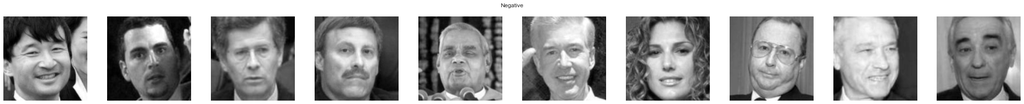

```python
fig_anchors, anchors = plt.subplots(1, 10, figsize=(30,3))
fig_pos, positives = plt.subplots(1, 10, figsize=(30,3))
fig_neg, negatives = plt.subplots(1, 10, figsize=(30,3))
for i in range(10):
    (anchor, positive, negative), _ = val_dataset[i]
    anchors[i].imshow(anchor[0], cmap="gray")
    anchors[i].axis("off")
    positives[i].imshow(positive[0], cmap="gray")
    positives[i].axis("off")
    negatives[i].imshow(negative[0], cmap="gray")
    negatives[i].axis("off")
fig_anchors.suptitle("Anchors")
fig_pos.suptitle("Positives")
fig_neg.suptitle("Negative")
plt.tight_layout()
```

```python
train_loader = torch.utils.data.DataLoader(dataset=train_dataset, batch_size=24, shuffle=True)
valid_loader = torch.utils.data.DataLoader(dataset=val_dataset, batch_size=24, shuffle=True)
test_loader = torch.utils.data.DataLoader(dataset=test_dataset, batch_size=24, shuffle=True)
```

```python
def weights_init(m):
    classname = m.__class__.__name__
    if classname.find('Conv') != -1:
        nn.init.normal_(m.weight.data, 0.0, 0.02)
    elif classname.find('BatchNorm') != -1:
        nn.init.normal_(m.weight.data, 1.0, 0.02)
        nn.init.constant_(m.bias.data, 0)
```

## Utils

```python
def smooth(f, K=5):
    """ Smoothing a function using a low-pass filter (mean) of size K """
    kernel = np.ones(K) / K
    f = np.concatenate([f[:int(K//2)], f, f[int(-K//2):]])  # to account for boundaries
    smooth_f = np.convolve(f, kernel, mode="same")
    smooth_f = smooth_f[K//2: -K//2]  # removing boundary-fixes
    return smooth_f


def save_model(model, optimizer, epoch, stats):
    """ Saving model checkpoint """

    if(not os.path.exists("checkpoints")):
        os.makedirs("checkpoints")
    savepath = f"checkpoints/checkpoint_fixedemb32_{epoch}.pth"

    torch.save({
        'epoch': epoch,
        'model_state_dict': model.state_dict(),
        'optimizer_state_dict': optimizer.state_dict(),
        'stats': stats
    }, savepath)
    return


def load_model(model, optimizer, savepath):
    """ Loading pretrained checkpoint """

    checkpoint = torch.load(savepath)
    model.load_state_dict(checkpoint['model_state_dict'])
    optimizer.load_state_dict(checkpoint['optimizer_state_dict'])
    epoch = checkpoint["epoch"]
    stats = checkpoint["stats"]

    return model, optimizer, epoch, stats


def count_model_params(model):
    """ Counting the number of learnable parameters in a nn.Module """
    num_params = sum(p.numel() for p in model.parameters() if p.requires_grad)
    return num_params

def visualize_progress(train_loss, val_loss, start=0):
    """ Visualizing loss and accuracy """
    fig, ax = plt.subplots(1,3)
    fig.set_size_inches(24,5)

    smooth_train = smooth(train_loss, 31)
    ax[0].plot(train_loss, c="blue", label="Loss", linewidth=3, alpha=0.5)
    ax[0].plot(smooth_train, c="red", label="Smoothed Loss", linewidth=3, alpha=1)
    ax[0].legend(loc="best")
    ax[0].set_xlabel("Iteration")
    ax[0].set_ylabel("CE Loss")
    ax[0].set_yscale("linear")
    ax[0].set_title("Training Progress (linear)")

    ax[1].plot(train_loss, c="blue", label="Loss", linewidth=3, alpha=0.5)
    ax[1].plot(smooth_train, c="red", label="Smoothed Loss", linewidth=3, alpha=1)
    ax[1].legend(loc="best")
    ax[1].set_xlabel("Iteration")
    ax[1].set_ylabel("CE Loss")
    ax[1].set_yscale("log")
    ax[1].set_title("Training Progress (log)")

    smooth_val = smooth(val_loss, 31)
    N_ITERS = len(val_loss)
    ax[2].plot(np.arange(start, N_ITERS)+start, val_loss[start:], c="blue", label="Loss", linewidth=3, alpha=0.5)
    ax[2].plot(np.arange(start, N_ITERS)+start, smooth_val[start:], c="red", label="Smoothed Loss", linewidth=3, alpha=1)
    ax[2].legend(loc="best")
    ax[2].set_xlabel("Iteration")
    ax[2].set_ylabel("CE Loss")
    ax[2].set_yscale("log")
    ax[2].set_title(f"Valid Progress")

    return


def display_projections(points, labels, ax=None, legend=None):
    """ Displaying low-dimensional data projections """

    COLORS = ['r', 'b', 'g', 'y', 'purple', 'orange', 'k', 'brown', 'grey',
          'c', "gold", "fuchsia", "lime", "darkred", "tomato", "navy"]
    legend = [f"Class {l}" for l in np.unique(labels)] if legend is None else legend
    if(ax is None):
        _, ax = plt.subplots(1,1,figsize=(12,6))
    count_times = [0,0,0,0]
    labeling = [1047.0, 1393.0, 1870.0, 1891.0]
    names = ["Colin_Powell","Donald_Rumsfeld","George_W_Bush","Gerhard_Schroeder"]
    k=0
    for i in labeling:
        for j in range(len(labels)-1):
            if(i==labels[j]):
                if(i==1047.0):
                    k=0
                elif(i==1393.0):
                    k=1
                elif(i==1870.0):
                    k=2
                elif(i==1891.0):
                    k=3
                count_times[k]=count_times[k]+1
                if(count_times[k]==1):
                    ax.scatter(points[j, 0], points[j, 1], label=names[k],c=COLORS[k])
                else:
                    ax.scatter(points[j, 0], points[j, 1], c=COLORS[k])
    plt.grid()
    ax.legend(loc="best")
```

# Siamese model: using Resnet18

```python
class NormLayer(nn.Module):
    """ Layer that computer embedding normalization """
    def __init__(self, l=2):
        """ Layer initializer """
        assert l in [1,2]
        super().__init__()
        self.l = l
        return

    def forward(self, x):
        """ Normalizing embeddings x. The shape of x is (B,D) """
        x_normalized = x / torch.norm(x, p=self.l, dim=-1, keepdim=True)
        return x_normalized
```

```python
class SiameseModel(nn.Module):
    """
    Implementation of a simple siamese model
    """
    def __init__(self, emb_dim=32, channels=[1, 32, 64, 128], in_spatial=(32,32)):
        """ Module initializer """
        super().__init__()
        n_layers = len(channels) - 1

        # convolutional feature extractor

        cnn1 = models.resnet18(pretrained=True)  # https://github.com/pytorch/vision/blob/master/torchvision/models/resnet.py
        # replacing classification head
        num_nuerons = cnn1.fc.in_features
        cnn1.fc = nn.Linear(num_nuerons, 320)
        self.cnn = cnn1


        # auxiliar layers
        self.flatten = nn.Flatten()
        self.norm = NormLayer()

        return

    def forward_one(self, x):
        """ Forwarding just one sample through the model """
        x = self.cnn(x)
        x_flat = self.flatten(x)
        #x_emb = self.fc(x_flat)
        x_emb_norm = self.norm(x_flat)
        return x_emb_norm

    def forward(self, anchor, positive, negative):
        """ Forwarding a triplet """
        anchor_emb = self.forward_one(anchor)
        positive_emb = self.forward_one(positive)
        negative_emb = self.forward_one(negative)
        return anchor_emb, positive_emb, negative_emb
```

```python
model = SiameseModel()
```

# Siamese model: using Resnet18 but fixed feature extractor

```python
class SiameseModel(nn.Module):
    """
    Implementation of a simple siamese model
    """
    def __init__(self, emb_dim=32, channels=[1, 32, 64, 128], in_spatial=(32,32)):
        """ Module initializer """
        super().__init__()
        n_layers = len(channels) - 1

        # convolutional feature extractor

        cnn1 = models.resnet18(pretrained=True)  # https://github.com/pytorch/vision/blob/master/torchvision/models/resnet.py
        # replacing classification head
        for param in cnn1.parameters():
            param.require_grad = False
        num_nuerons = cnn1.fc.in_features
        cnn1.fc = nn.Linear(num_nuerons, 320)
        self.cnn = cnn1


        # auxiliar layers
        self.flatten = nn.Flatten()
        self.norm = NormLayer()

        return

    def forward_one(self, x):
        """ Forwarding just one sample through the model """
        x = self.cnn(x)
        x_flat = self.flatten(x)
        #x_emb = self.fc(x_flat)
        x_emb_norm = self.norm(x_flat)
        return x_emb_norm

    def forward(self, anchor, positive, negative):
        """ Forwarding a triplet """
        anchor_emb = self.forward_one(anchor)
        positive_emb = self.forward_one(positive)
        negative_emb = self.forward_one(negative)
        return anchor_emb, positive_emb, negative_emb
```

```python
model = SiameseModel()
```

```python
#model.apply(weights_init)
```

```python
print(f"Model has {count_model_params(model)} parameters")
model
```

```
Model has 11340672 parameters
```

```
SiameseModel(
  (cnn): ResNet(
    (conv1): Conv2d(3, 64, kernel_size=(7, 7), stride=(2, 2), padding=(3, 3), bias=False)
    (bn1): BatchNorm2d(64, eps=1e-05, momentum=0.1, affine=True, track_running_stats=True)
    (relu): ReLU(inplace=True)
    (maxpool): MaxPool2d(kernel_size=3, stride=2, padding=1, dilation=1, ceil_mode=False)
    (layer1): Sequential(
      (0): BasicBlock(
        (conv1): Conv2d(64, 64, kernel_size=(3, 3), stride=(1, 1), padding=(1, 1), bias=False)
        (bn1): BatchNorm2d(64, eps=1e-05, momentum=0.1, affine=True, track_running_stats=True)
        (relu): ReLU(inplace=True)
        (conv2): Conv2d(64, 64, kernel_size=(3, 3), stride=(1, 1), padding=(1, 1), bias=False)
        (bn2): BatchNorm2d(64, eps=1e-05, momentum=0.1, affine=True, track_running_stats=True)
      )
      (1): BasicBlock(
        (conv1): Conv2d(64, 64, kernel_size=(3, 3), stride=(1, 1), padding=(1, 1), bias=False)
        (bn1): BatchNorm2d(64, eps=1e-05, momentum=0.1, affine=True, track_running_stats=True)
        (relu): ReLU(inplace=True)
        (conv2): Conv2d(64, 64, kernel_size=(3, 3), stride=(1, 1), padding=(1, 1), bias=False)
        (bn2): BatchNorm2d(64, eps=1e-05, momentum=0.1, affine=True, track_running_stats=True)
      )
    )
    (layer2): Sequential(
      (0): BasicBlock(
        (conv1): Conv2d(64, 128, kernel_size=(3, 3), stride=(2, 2), padding=(1, 1), bias=False)
        (bn1): BatchNorm2d(128, eps=1e-05, momentum=0.1, affine=True, track_running_stats=True)
        (relu): ReLU(inplace=True)
        (conv2): Conv2d(128, 128, kernel_size=(3, 3), stride=(1, 1), padding=(1, 1), bias=False)
        (bn2): BatchNorm2d(128, eps=1e-05, momentum=0.1, affine=True, track_running_stats=True)
        (downsample): Sequential(
          (0): Conv2d(64, 128, kernel_size=(1, 1), stride=(2, 2), bias=False)
          (1): BatchNorm2d(128, eps=1e-05, momentum=0.1, affine=True, track_running_stats=True)
        )
      )
      (1): BasicBlock(
        (conv1): Conv2d(128, 128, kernel_size=(3, 3), stride=(1, 1), padding=(1, 1), bias=False)
        (bn1): BatchNorm2d(128, eps=1e-05, momentum=0.1, affine=True, track_running_stats=True)
        (relu): ReLU(inplace=True)
        (conv2): Conv2d(128, 128, kernel_size=(3, 3), stride=(1, 1), padding=(1, 1), bias=False)
        (bn2): BatchNorm2d(128, eps=1e-05, momentum=0.1, affine=True, track_running_stats=True)
```

[output cut: 33 more lines]

```
      )
      (1): BasicBlock(
        (conv1): Conv2d(512, 512, kernel_size=(3, 3), stride=(1, 1), padding=(1, 1), bias=False)
        (bn1): BatchNorm2d(512, eps=1e-05, momentum=0.1, affine=True, track_running_stats=True)
        (relu): ReLU(inplace=True)
        (conv2): Conv2d(512, 512, kernel_size=(3, 3), stride=(1, 1), padding=(1, 1), bias=False)
        (bn2): BatchNorm2d(512, eps=1e-05, momentum=0.1, affine=True, track_running_stats=True)
      )
    )
    (avgpool): AdaptiveAvgPool2d(output_size=(1, 1))
    (fc): Linear(in_features=512, out_features=320, bias=True)
  )
  (flatten): Flatten(start_dim=1, end_dim=-1)
  (norm): NormLayer()
)
```

# Training

```python
class TripletLoss(nn.Module):
    """ Implementation of the triplet loss function """
    def __init__(self, margin=0.2, reduce="mean"):
        """ Module initializer """
        assert reduce in ["mean", "sum"]
        super().__init__()
        self.margin = margin
        self.reduce = reduce
        return

    def forward(self, anchor, positive, negative):
        """ Computing pairwise distances and loss functions """
        # L2 distances
        d_ap = (anchor - positive).pow(2).sum(dim=-1)
        d_an = (anchor - negative).pow(2).sum(dim=-1)

        # triplet loss function
        loss = (d_ap - d_an + self.margin)
        loss = torch.maximum(loss, torch.zeros_like(loss))

        # averaging or summing
        if(self.reduce == "mean"):
            loss = torch.mean(loss)
        else:
            loss = torch.sum(loss)

        return loss
```

```python
class Trainer:
    """
    Class for training and validating a siamese model
    """

    def __init__(self, model, criterion, train_loader, valid_loader, n_iters=1e4):
        """ Trainer initializer """
        self.model = model
        self.criterion = criterion
        self.train_loader = train_loader
        self.valid_loader = valid_loader

        self.n_iters = int(n_iters)
        self.optimizer = torch.optim.Adam(model.parameters(), lr=3e-5, weight_decay=1e-5)
        self.device = torch.device("cuda" if torch.cuda.is_available() else "cpu")
        #self.device = "cpu"
        self.model.to(self.device)
        self.criterion.to(self.device)
        self.train_loss = []
        self.valid_loss = []
        return

    @torch.no_grad()
    def valid_step(self, val_iters=100):
        """ Some validation iterations """
        self.model.eval()
        cur_losses = []
        for i, ((anchors, positives, negatives),_) in enumerate(self.valid_loader):
            # setting inputs to GPU
            anchors = anchors.to(self.device)
            positives = positives.to(self.device)
            negatives = negatives.to(self.device)

            # forward pass and triplet loss
            anchor_emb, positive_emb, negative_emb = self.model(anchors, positives, negatives)
            loss = self.criterion(anchor_emb, positive_emb, negative_emb)
            cur_losses.append(loss.item())

            if(i >= val_iters):
                break

        self.valid_loss += cur_losses
        self.model.train()

        return cur_losses

    def fit(self):
        """ Train/Validation loop """

        self.iter_ = 0
        progress_bar = tqdm(total=self.n_iters, initial=0)

        for i in range(self.n_iters):
            for (anchors, positives, negatives), _ in self.train_loader:
                # setting inputs to GPU
                anchors = anchors.to(self.device)
                positives = positives.to(self.device)
                negatives = negatives.to(self.device)

                # forward pass and triplet loss
                anchor_emb, positive_emb, negative_emb = self.model(anchors, positives, negatives)
                loss = self.criterion(anchor_emb, positive_emb, negative_emb)
                self.train_loss.append(loss.item())

                # optimization
                self.optimizer.zero_grad()
                loss.backward()
                self.optimizer.step()

                # updating progress bar
                progress_bar.set_description(f"Train Iter {self.iter_}: Loss={round(loss.item(),5)})")

                # doing some validation every once in a while
                if(self.iter_ % 250 == 0):
                    cur_losses = self.valid_step()
                    print(f"Valid loss @ iteration {self.iter_}: Loss={np.mean(cur_losses)}")

                self.iter_ = self.iter_+1
                if(self.iter_ >= self.n_iters):
                    break
            if(self.iter_ >= self.n_iters):
                break
        return
```

```python
device = torch.device("cuda" if torch.cuda.is_available() else "cpu")
device
```

```
device(type='cuda')
```

```python
criterion = TripletLoss(margin=0.2).to(device)
```

```python
model=model.to(device)
```

```python
trainer = Trainer(model=model, criterion=criterion, train_loader=train_loader, valid_loader=valid_loader, n_iters=10000)
```

```python
next(model.parameters()).is_cuda
```

```
True
```

```python
trainer.fit()
```

```
Valid loss @ iteration 0: Loss=0.04515688134623425
```

```
Valid loss @ iteration 250: Loss=0.024604065271670975
```

```
Valid loss @ iteration 500: Loss=0.013828788513776436
```

```
Valid loss @ iteration 750: Loss=0.014269107532332523
```

```
Valid loss @ iteration 1000: Loss=0.01193838994575864
```

```
Valid loss @ iteration 1250: Loss=0.010305501310150638
```

```
Valid loss @ iteration 1500: Loss=0.009560454044341376
```

```
Valid loss @ iteration 1750: Loss=0.00979932276667179
```

```
Valid loss @ iteration 2000: Loss=0.010569577884217281
```

```
Valid loss @ iteration 2250: Loss=0.008886164450987485
```

```
Valid loss @ iteration 2500: Loss=0.010141065755825756
```

```
Valid loss @ iteration 2750: Loss=0.00995204171097915
```

```
Valid loss @ iteration 3000: Loss=0.009298549082900752
```

```
Valid loss @ iteration 3250: Loss=0.006794570699033405
```

```
Valid loss @ iteration 3500: Loss=0.005759460428158664
```

```
Valid loss @ iteration 3750: Loss=0.007639058809477969
```

```
Valid loss @ iteration 4000: Loss=0.007848123009829405
```

```
Valid loss @ iteration 4250: Loss=0.006120479142867096
```

```
Valid loss @ iteration 4500: Loss=0.009218810717270355
```

```
Valid loss @ iteration 4750: Loss=0.00925734436826869
```

```
Valid loss @ iteration 5000: Loss=0.007850845532846592
```

```
Valid loss @ iteration 5250: Loss=0.008191228219878948
```

```
Valid loss @ iteration 5500: Loss=0.007519545222056054
```

```
Valid loss @ iteration 5750: Loss=0.006924234095398181
```

```
Valid loss @ iteration 6000: Loss=0.006181121476748515
```

```
Valid loss @ iteration 6250: Loss=0.005587230452441699
```

```
Valid loss @ iteration 6500: Loss=0.007391173353729148
```

```
Valid loss @ iteration 6750: Loss=0.005610548310436397
```

```
Valid loss @ iteration 7000: Loss=0.0047155367030340825
```

```
Valid loss @ iteration 7250: Loss=0.005327366194077989
```

```
Valid loss @ iteration 7500: Loss=0.005486414218986673
```

```
Valid loss @ iteration 7750: Loss=0.005523211161267855
```

```
Valid loss @ iteration 8000: Loss=0.005368548798114283
```

```
Valid loss @ iteration 8250: Loss=0.006494291580046203
```

```
Valid loss @ iteration 8500: Loss=0.006357184698399145
```

```
Valid loss @ iteration 8750: Loss=0.007029741926955813
```

```
Valid loss @ iteration 9000: Loss=0.0060219416045583785
```

```
Valid loss @ iteration 9250: Loss=0.006223521231038917
```

```
Valid loss @ iteration 9500: Loss=0.004127536907054448
```

```
Valid loss @ iteration 9750: Loss=0.005462576553413999
```

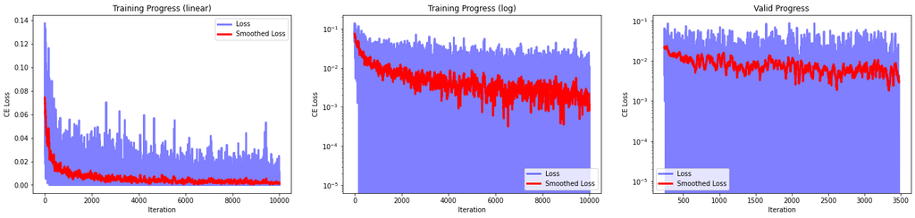

```python
visualize_progress(trainer.train_loss, trainer.valid_loss, start=120)
```

```python
stats = {
    "train_loss": trainer.train_loss,
    "valid_loss": trainer.valid_loss
}
save_model(trainer.model, trainer.optimizer, trainer.iter_, stats)
```

# NOTE: Below are results from saved models. If you want to see results from current model then please, comment out the very next line and continue.

## This drive folder has the models used below uploaded: https://drive.google.com/drive/folders/1d9e_2SHRy9EDsOGbsBJawbYlX1KLwbK3?usp=sharing

# Loading a saved model here with embedding size of 32 and using fine-tuned resnet

```python
model, optimizer, epoch, stats = load_model(trainer.model, trainer.optimizer, savepath="checkpoints/checkpoint_epoch_10000.pth")
```

### The plots looks nice as they show the model is learning well.

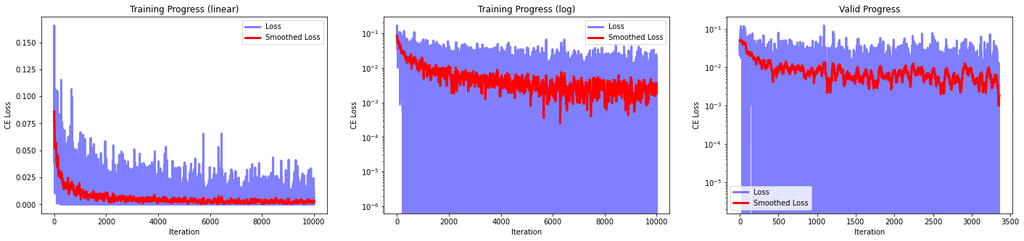

```python
visualize_progress(stats["train_loss"], stats["valid_loss"], start=0)
```

# Visualizing Embeddings

```python
from sklearn.decomposition import PCA
from sklearn.manifold import TSNE

from sklearn.cluster import KMeans
from sklearn.metrics import adjusted_rand_score
```

```python
# model = trainer.model
device = trainer.device
model = model.eval()
```

```python
(img,_,_),(lbl,_,_) = next(iter(test_loader))
```

```python
img.shape
```

```
torch.Size([24, 3, 200, 200])
```

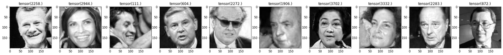

```python
fig, ax = plt.subplots(1,10, figsize=(30,3))
for i in range(10):
    ax[i].imshow(img[i,0], cmap="gray")
    ax[i].set_title(lbl[i])
```

```python
imgs_flat = []
embs = []
labels = []
with torch.no_grad():
    for (anchor, _, _), (lbl,_, _) in test_loader:
        anchor = anchor.to(device)
        anchor_emb = model.forward_one(anchor)

        labels.append(lbl)
        embs.append(anchor_emb.cpu())
        imgs_flat.append(anchor.cpu().flatten(1))

labels = np.concatenate(labels)
embs = np.concatenate(embs)
imgs_flat = np.concatenate(imgs_flat)
```

```python
labels[:10]
```

```
array([2947., 5480., 2885., 5557., 2329.,  380., 4785., 4046., 1047.,
       4198.], dtype=float32)
```

```python
imgs_flat.shape
```

```
(2233, 120000)
```

```python
embs.shape
```

```
(2233, 32)
```

```python
values, counts = np.unique(labels, return_counts=True)
```

```python
# A preprocessing step that involved finding out which person had the most repetitions in test model
res = list(zip(*np.unique(labels, return_counts=True)))
for i in range(len(res)):
    if(res[i][1]==91 or res[i][1]==42 or res[i][1]==17 or res[i][1]==12  ):
        print(res[i][0])
```

```
1047.0
1393.0
1870.0
1891.0
```

```python
pca_imgs = PCA(n_components=2).fit_transform(imgs_flat)
pca_embs = PCA(n_components=2).fit_transform(embs)
```

```python
def display_projections(points, labels, ax=None, legend=None):
    """ Displaying low-dimensional data projections """

    COLORS = ['r', 'b', 'g', 'y', 'purple', 'orange', 'k', 'brown', 'grey',
          'c', "gold", "fuchsia", "lime", "darkred", "tomato", "navy"]
    legend = [f"Class {l}" for l in np.unique(labels)] if legend is None else legend
    if(ax is None):
        _, ax = plt.subplots(1,1,figsize=(12,6))
    count_times = [0,0,0,0]
    labeling = [1047.0, 1393.0, 1870.0, 1891.0]
    names = ["Colin_Powell","Donald_Rumsfeld","George_W_Bush","Gerhard_Schroeder"]
    k=0
    for i in labeling:
        for j in range(len(labels)-1):
            if(i==labels[j]):
                if(i==1047.0):
                    k=0
                elif(i==1393.0):
                    k=1
                elif(i==1870.0):
                    k=2
                elif(i==1891.0):
                    k=3
                count_times[k]=count_times[k]+1
                if(count_times[k]==1):
                    ax.scatter(points[j, 0], points[j, 1], label=names[k],c=COLORS[k])
                else:
                    ax.scatter(points[j, 0], points[j, 1], c=COLORS[k])
    plt.grid()
    ax.legend(loc="best")
```

```python
N = 2232
tsne_imgs = TSNE(n_components=2).fit_transform(imgs_flat[:N])
tsne_embs = TSNE(n_components=2).fit_transform(embs[:N])
```

## In the plots below both pca projections are bad but embeddings looks more organised and close to clusters

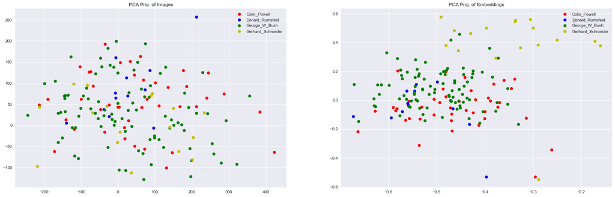

```python
N = 2232
plt.style.use('seaborn')
fig,ax = plt.subplots(1,2,figsize=(26,8))
display_projections(pca_imgs[:N], labels[:N], ax=ax[0], legend=test_dataset.labels)
ax[0].set_title("PCA Proj. of Images")
display_projections(pca_embs[:N], labels[:N], ax=ax[1], legend=test_dataset.labels)
ax[1].set_title("PCA Proj. of Embeddings")
plt.show()
```

## In the tsne plots we see a really nice clusters of embedding size of just 32 while projection of images is not so nice

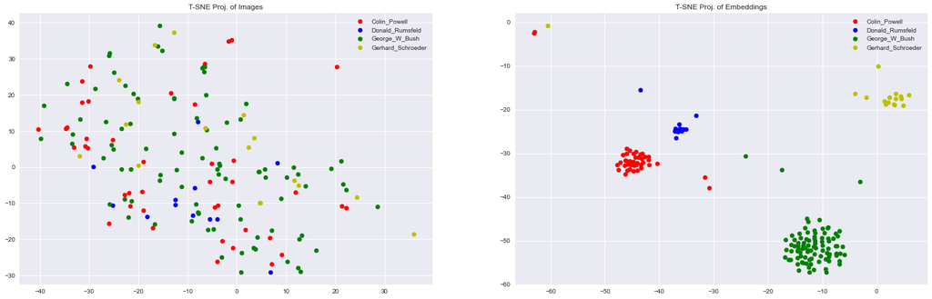

```python
count_times = [0,0,0,0]
fig,ax = plt.subplots(1,2,figsize=(26,8))
display_projections(tsne_imgs[:N], labels[:N], ax=ax[0], legend=test_dataset.labels)
ax[0].set_title("T-SNE Proj. of Images")
display_projections(tsne_embs[:N], labels[:N], ax=ax[1], legend=test_dataset.labels)
ax[1].set_title("T-SNE Proj. of Embeddings")
plt.show()
```

# Clustering

```python
from sklearn.cluster import KMeans
from sklearn.metrics import adjusted_rand_score
```

```python
kmeans_imgs = KMeans(n_clusters=4, random_state=0).fit(imgs_flat)
kmeans_embs = KMeans(n_clusters=4, random_state=0).fit(embs)
```

```python
ari_imgs = adjusted_rand_score(labels, kmeans_imgs.labels_)
ari_embs = adjusted_rand_score(labels, kmeans_embs.labels_)
```

```python
print(f"Clustering images achieves  ARI={round(ari_imgs*100,2)}%")
print(f"Clustering embeddings achieves ARI={round(ari_embs*100,2)}%")
```

```
Clustering images achieves  ARI=0.1%
Clustering embeddings achieves ARI=1.35%
```

```python
print(f"Compression ratio: {embs.shape[-1]}/{imgs_flat.shape[-1]}  = {round(embs.shape[-1]/imgs_flat.shape[-1] * 100, 2)}%")
```

```
Compression ratio: 32/120000  = 0.03%
```

# Loading a saved model here with embedding size of 32 and using fixed-features resnet

```python
model, optimizer, epoch, stats = load_model(trainer.model, trainer.optimizer, savepath="checkpoints/checkpoint_fixedemb32_10000.pth")
```

### The plots looks nice again and they show the model learnt well.

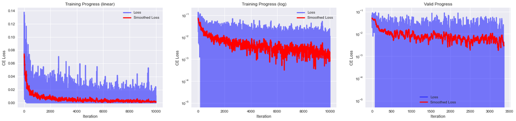

```python
visualize_progress(stats["train_loss"], stats["valid_loss"], start=0)
```

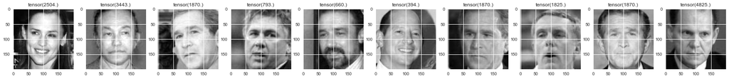

```python
# model = trainer.model
device = trainer.device
model = model.eval()

(img,_,_),(lbl,_,_) = next(iter(test_loader))

fig, ax = plt.subplots(1,10, figsize=(30,3))
for i in range(10):
    ax[i].imshow(img[i,0], cmap="gray")
    ax[i].set_title(lbl[i])
```

```python
imgs_flat = []
embs = []
labels = []
with torch.no_grad():
    for (anchor, _, _), (lbl,_, _) in test_loader:
        anchor = anchor.to(device)
        anchor_emb = model.forward_one(anchor)

        labels.append(lbl)
        embs.append(anchor_emb.cpu())
        imgs_flat.append(anchor.cpu().flatten(1))

labels = np.concatenate(labels)
embs = np.concatenate(embs)
imgs_flat = np.concatenate(imgs_flat)

pca_imgs = PCA(n_components=2).fit_transform(imgs_flat)
pca_embs = PCA(n_components=2).fit_transform(embs)
```

```python
N = 2232
tsne_imgs = TSNE(n_components=2).fit_transform(imgs_flat[:N])
tsne_embs = TSNE(n_components=2).fit_transform(embs[:N])
```

## In the plot below, pca projections looks a lot better than the fine tuned resnet above as cluster are starting to look a lot better.

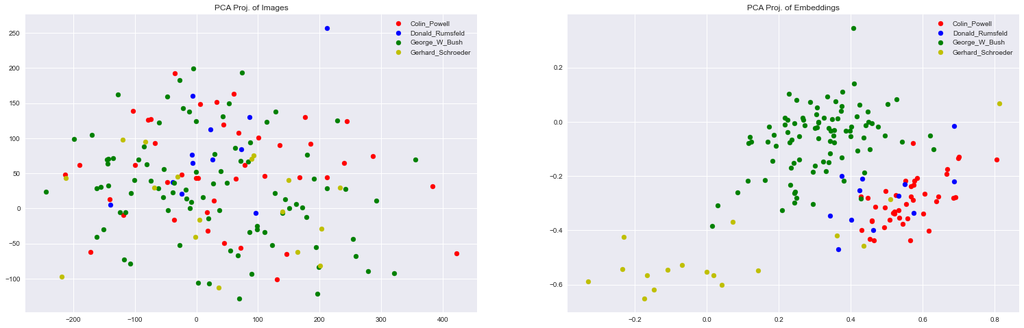

```python
N = 2232
plt.style.use('seaborn')
fig,ax = plt.subplots(1,2,figsize=(26,8))
display_projections(pca_imgs[:N], labels[:N], ax=ax[0], legend=test_dataset.labels)
ax[0].set_title("PCA Proj. of Images")
display_projections(pca_embs[:N], labels[:N], ax=ax[1], legend=test_dataset.labels)
ax[1].set_title("PCA Proj. of Embeddings")
plt.show()
```

## In the tsne plots we see a really nice clusters of embedding size of just 32 but not slightly worse than what we achieved in fine-tuned resnet.

## Projections of images are bad again.

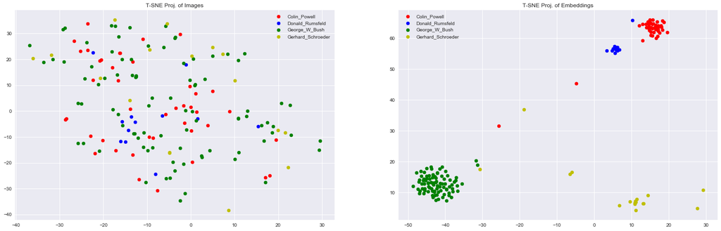

```python
count_times = [0,0,0,0]
fig,ax = plt.subplots(1,2,figsize=(26,8))
display_projections(tsne_imgs[:N], labels[:N], ax=ax[0], legend=test_dataset.labels)
ax[0].set_title("T-SNE Proj. of Images")
display_projections(tsne_embs[:N], labels[:N], ax=ax[1], legend=test_dataset.labels)
ax[1].set_title("T-SNE Proj. of Embeddings")
plt.show()
```

# Clustering

```python
kmeans_imgs = KMeans(n_clusters=4, random_state=0).fit(imgs_flat)
kmeans_embs = KMeans(n_clusters=4, random_state=0).fit(embs)
```

```python
ari_imgs = adjusted_rand_score(labels, kmeans_imgs.labels_)
ari_embs = adjusted_rand_score(labels, kmeans_embs.labels_)
```

```python
print(f"Clustering images achieves  ARI={round(ari_imgs*100,2)}%")
print(f"Clustering embeddings achieves ARI={round(ari_embs*100,2)}%")
```

```
Clustering images achieves  ARI=0.11%
Clustering embeddings achieves ARI=1.3%
```

```python
print(f"Compression ratio: {embs.shape[-1]}/{imgs_flat.shape[-1]}  = {round(embs.shape[-1]/imgs_flat.shape[-1] * 100, 2)}%")
```

```
Compression ratio: 32/120000  = 0.03%
```

# Loading a saved model here with embedding size of 320 and using fine-tuned resnet

```python
model, optimizer, epoch, stats = load_model(trainer.model, trainer.optimizer, savepath="checkpoints/checkpoint_epochemb320_4000.pth")
```

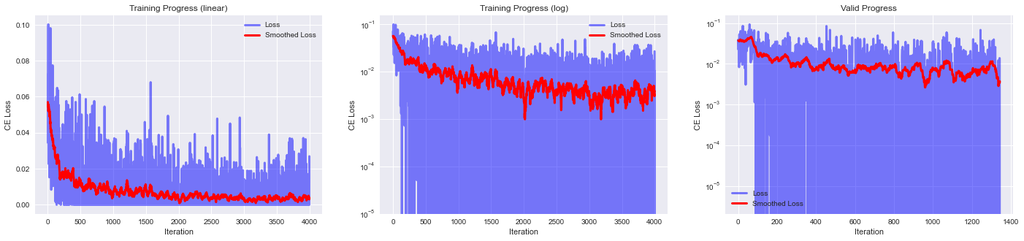

```python
visualize_progress(stats["train_loss"], stats["valid_loss"], start=0)
```

```python
# model = trainer.model
device = trainer.device
model = model.eval()

(img,_,_),(lbl,_,_) = next(iter(test_loader))
```

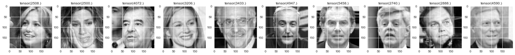

```python
fig, ax = plt.subplots(1,10, figsize=(30,3))
for i in range(10):
    ax[i].imshow(img[i,0], cmap="gray")
    ax[i].set_title(lbl[i])
```

```python
imgs_flat = []
embs = []
labels = []
with torch.no_grad():
    for (anchor, _, _), (lbl,_, _) in test_loader:
        anchor = anchor.to(device)
        anchor_emb = model.forward_one(anchor)

        labels.append(lbl)
        embs.append(anchor_emb.cpu())
        imgs_flat.append(anchor.cpu().flatten(1))

labels = np.concatenate(labels)
embs = np.concatenate(embs)
imgs_flat = np.concatenate(imgs_flat)
```

```python
pca_imgs = PCA(n_components=2).fit_transform(imgs_flat)
pca_embs = PCA(n_components=2).fit_transform(embs)
```

```python
N = 2232
tsne_imgs = TSNE(n_components=2).fit_transform(imgs_flat[:N])
tsne_embs = TSNE(n_components=2).fit_transform(embs[:N])
```

## In the plot below, pca projections looks a lot better than the fine tuned resnet with embed size 32 but a little off than fixed feature resnet with size 32.

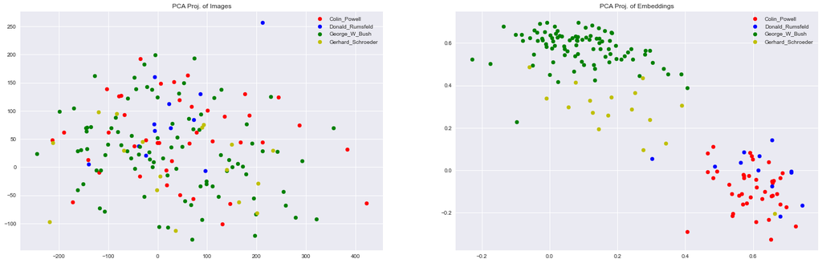

```python
N = 2232
plt.style.use('seaborn')
fig,ax = plt.subplots(1,2,figsize=(26,8))
display_projections(pca_imgs[:N], labels[:N], ax=ax[0], legend=test_dataset.labels)
ax[0].set_title("PCA Proj. of Images")
display_projections(pca_embs[:N], labels[:N], ax=ax[1], legend=test_dataset.labels)
ax[1].set_title("PCA Proj. of Embeddings")
plt.show()
```

## In comparison to fine tuned resnet with embedding size 32, the fine tuned resnet with emb size 320 looks a little better

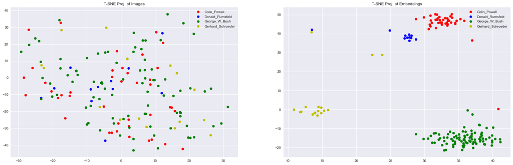

```python
fig,ax = plt.subplots(1,2,figsize=(26,8))
display_projections(tsne_imgs[:N], labels[:N], ax=ax[0], legend=test_dataset.labels)
ax[0].set_title("T-SNE Proj. of Images")
display_projections(tsne_embs[:N], labels[:N], ax=ax[1], legend=test_dataset.labels)
ax[1].set_title("T-SNE Proj. of Embeddings")
plt.show()
```

# Clustering

```python
kmeans_imgs = KMeans(n_clusters=4, random_state=0).fit(imgs_flat)
kmeans_embs = KMeans(n_clusters=4, random_state=0).fit(embs)
```

```python
ari_imgs = adjusted_rand_score(labels, kmeans_imgs.labels_)
ari_embs = adjusted_rand_score(labels, kmeans_embs.labels_)
```

```python
print(f"Clustering images achieves  ARI={round(ari_imgs*100,2)}%")
print(f"Clustering embeddings achieves ARI={round(ari_embs*100,2)}%")
```

```
Clustering images achieves  ARI=0.11%
Clustering embeddings achieves ARI=1.39%
```

```python
print(f"Compression ratio: {embs.shape[-1]}/{imgs_flat.shape[-1]}  = {round(embs.shape[-1]/imgs_flat.shape[-1] * 100, 2)}%")
```

```
Compression ratio: 320/120000  = 0.27%
```

# Loading a saved model here with embedding size of 320 and using fixed-feature resnet

```python
model, optimizer, epoch, stats = load_model(trainer.model, trainer.optimizer, savepath="checkpoints/checkpoint_fixedemb320_4000.pth")
```

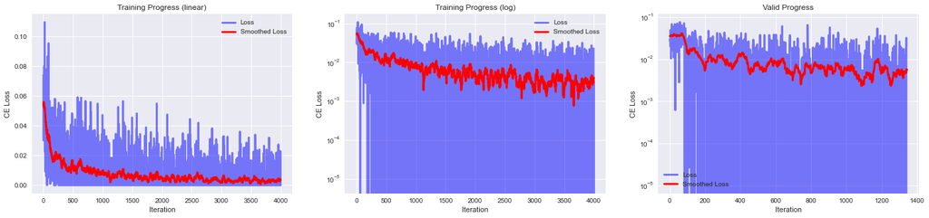

```python
visualize_progress(stats["train_loss"], stats["valid_loss"], start=0)
```

```python
# model = trainer.model
device = trainer.device
model = model.eval()

(img,_,_),(lbl,_,_) = next(iter(test_loader))
```

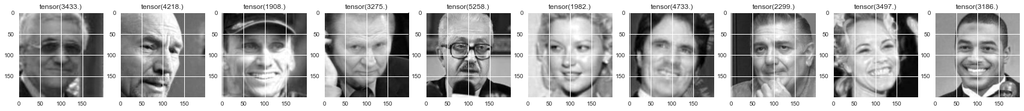

```python
fig, ax = plt.subplots(1,10, figsize=(30,3))
for i in range(10):
    ax[i].imshow(img[i,0], cmap="gray")
    ax[i].set_title(lbl[i])
```

```python
imgs_flat = []
embs = []
labels = []
with torch.no_grad():
    for (anchor, _, _), (lbl,_, _) in test_loader:
        anchor = anchor.to(device)
        anchor_emb = model.forward_one(anchor)

        labels.append(lbl)
        embs.append(anchor_emb.cpu())
        imgs_flat.append(anchor.cpu().flatten(1))

labels = np.concatenate(labels)
embs = np.concatenate(embs)
imgs_flat = np.concatenate(imgs_flat)
```

```python
pca_imgs = PCA(n_components=2).fit_transform(imgs_flat)
pca_embs = PCA(n_components=2).fit_transform(embs)
```

```python
N = 2232
tsne_imgs = TSNE(n_components=2).fit_transform(imgs_flat[:N])
tsne_embs = TSNE(n_components=2).fit_transform(embs[:N])
```

## In the plot below, pca projections looks a lot better than the fine tuned resnet with embed size 320.

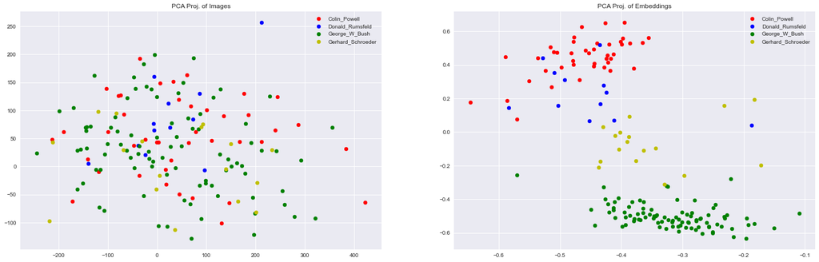

```python
N = 2232
plt.style.use('seaborn')
fig,ax = plt.subplots(1,2,figsize=(26,8))
display_projections(pca_imgs[:N], labels[:N], ax=ax[0], legend=test_dataset.labels)
ax[0].set_title("PCA Proj. of Images")
display_projections(pca_embs[:N], labels[:N], ax=ax[1], legend=test_dataset.labels)
ax[1].set_title("PCA Proj. of Embeddings")
plt.show()
```

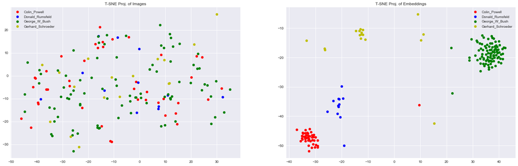

```python
fig,ax = plt.subplots(1,2,figsize=(26,8))
display_projections(tsne_imgs[:N], labels[:N], ax=ax[0], legend=test_dataset.labels)
ax[0].set_title("T-SNE Proj. of Images")
display_projections(tsne_embs[:N], labels[:N], ax=ax[1], legend=test_dataset.labels)
ax[1].set_title("T-SNE Proj. of Embeddings")
plt.show()
```

```python
kmeans_imgs = KMeans(n_clusters=4, random_state=0).fit(imgs_flat)
kmeans_embs = KMeans(n_clusters=4, random_state=0).fit(embs)
```

```python
ari_imgs = adjusted_rand_score(labels, kmeans_imgs.labels_)
ari_embs = adjusted_rand_score(labels, kmeans_embs.labels_)
```

```python
print(f"Clustering images achieves  ARI={round(ari_imgs*100,2)}%")
print(f"Clustering embeddings achieves ARI={round(ari_embs*100,2)}%")
```

```
Clustering images achieves  ARI=0.11%
Clustering embeddings achieves ARI=1.38%
```

```python
print(f"Compression ratio: {embs.shape[-1]}/{imgs_flat.shape[-1]}  = {round(embs.shape[-1]/imgs_flat.shape[-1] * 100, 2)}%")
```

```
Compression ratio: 320/120000  = 0.27%
```